# SU_25_River_Rockfish_Proj_V0.7

General data:

Ambient data:

Sodium Parametric Assessment Sodium Normality Residual QQplot

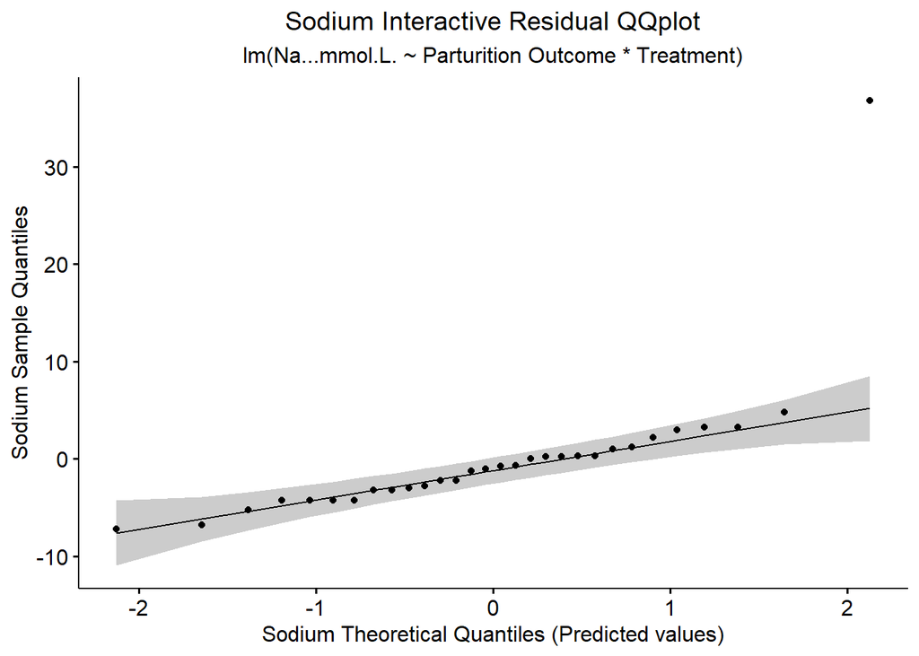

```r
# Sodium: Na+
# Parametric Assumptions:

# Assessing Normality
# Normality Plots
# Note: If data is non-normal considering applying transformation

# lm model of general data
sodium_lm_int <- lm(Na...mmol.L. ~ Pregnant.Or.Atresia * Ambient.Or.OAH, data = General_Samples)

# View all residual plots
#plot(sodium_lm_int)

sodium_res_int_qqplot <- ggqqplot(residuals(sodium_lm_int)) +
labs(title = "Sodium Interactive Residual QQplot",
     subtitle = "lm(Na...mmol.L. ~ Parturition Outcome * Treatment)",
                               x = "Sodium Theoretical Quantiles (Predicted values)",
                               y = "Sodium Sample Quantiles") +
  theme(plot.title = element_text(hjust = 0.5),
        plot.subtitle = element_text(hjust = 0.5))
print(sodium_res_int_qqplot)
```

Review Normality Residual QQplot (normality conditions met?):

General data:

Sodium Parametric Assessment Ambient Normality Residual QQplot

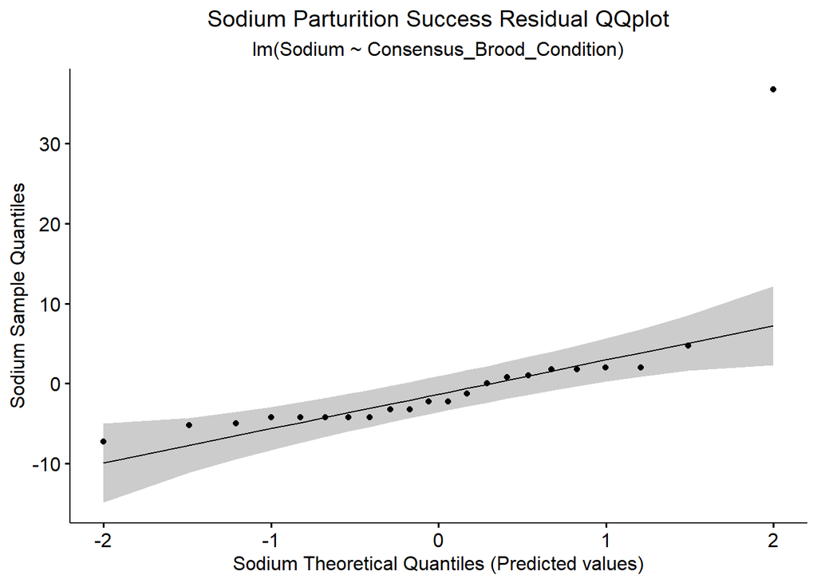

```r
# Sodium: Na+
# Parametric Assumptions

# Assessing Normality
# Normality Plots

# lm model of ambient data
sodium_lm_ambient <- lm(Na...mmol.L. ~ Consensus_Brood_Condition, data = Ambient_Only_Samples)

# View all residual plots
#plot(sodium_lm_ambient)

sodium_res_ambient_qqplot <- ggqqplot(residuals(sodium_lm_ambient)) +
labs(title = "Sodium Parturition Success Residual QQplot",
     subtitle = "lm(Sodium ~ Consensus_Brood_Condition)",
                               x = "Sodium Theoretical Quantiles (Predicted values)",
                               y = "Sodium Sample Quantiles") +
  theme(plot.title = element_text(hjust = 0.5),
        plot.subtitle = element_text(hjust = 0.5))
print(sodium_res_ambient_qqplot)
```

Review Normality Residual QQplot (normality conditions met?):

Ambient data:

Sodium Parametric Assessment Testing Normality

```r
# Sodium: Na+
# Parametric Assumptions

# Assessing Normality

# Analytical Test: Options listed below
# - Shapiro Test = for piping, shapiro_test() or in base r shapiro.test(): normal distribution

# Note: Shapiro test is sensitive to sample size, small n often pass normality, so review both visuals and test results to assess if normality conditions are met or not

# Note Error Message: error in `shapiro.test()`: ! sample size must be between 3 and 5000

# Shapiro.test for General Samples
General_Samples %>% shapiro_test(Na...mmol.L.)
```

```
## # A tibble: 1 × 3
##   variable     statistic             p
##   <chr>            <dbl>         <dbl>
## 1 Na...mmol.L.     0.509 0.00000000662
```

```r
General_Samples %>%
  group_by(Ambient.Or.OAH, Pregnant.Or.Atresia) %>%
  shapiro_test(Na...mmol.L.)
```

```
## # A tibble: 4 × 5
##   Ambient.Or.OAH Pregnant.Or.Atresia variable     statistic         p
##   <chr>          <chr>               <chr>            <dbl>     <dbl>
## 1 Ambient        Atresia             Na...mmol.L.     0.512 0.0000125
## 2 Ambient        Post Parturition    Na...mmol.L.     0.890 0.202
## 3 OAH            Atresia             Na...mmol.L.     0.999 1.00
## 4 OAH            Post Parturition    Na...mmol.L.     0.75  0
```

```r
# Shapito.test for Ambient Samples
Ambient_Only_Samples %>% shapiro_test(Na...mmol.L.)
```

```
## # A tibble: 1 × 3
##   variable     statistic           p
##   <chr>            <dbl>       <dbl>
## 1 Na...mmol.L.     0.518 0.000000196
```

```r
# Ambient_Only_Samples %>%
#   group_by(Consensus_Brood_Condition) %>%
#   shapiro_test(Na...mmol.L.)
```

Review of Shapiro-Wilk test (normality conditions met?):

General data:

Ambient data:

Sodium Parametric Assessment Testing Normality

```r
# Sodium: Na+
# Parametric Assumptions

# Assessing Normality

# Descriptive stat test: Stat.desc
# Z-score reflected in 'skew.2SE' and 'kurt.2SE'
# If these values are below 0.96 this indicates normality

# Note these values are sensitive to sample size, and are most effective for relatively small sample sizes approximately n = 30-50 range

# Note Alternative methods, all appear to display same results, not sure exactly how to incorporate an lm or aov model into the stat.desc function...

# General samples
General_Samples %>%
  summarise(Na...mmol.L., Ambient.Or.OAH, Pregnant.Or.Atresia) %>%
  stat.desc(norm = TRUE)
```

```
##              Na...mmol.L. Ambient.Or.OAH Pregnant.Or.Atresia
## nbr.val      3.000000e+01             NA                  NA
## nbr.null     0.000000e+00             NA                  NA
## nbr.na       0.000000e+00             NA                  NA
## min          1.690000e+02             NA                  NA
## max          2.180000e+02             NA                  NA
## range        4.900000e+01             NA                  NA
## sum          5.341000e+03             NA                  NA
## median       1.770000e+02             NA                  NA
## mean         1.780333e+02             NA                  NA
## SE.mean      1.485937e+00             NA                  NA
## CI.mean.0.95 3.039082e+00             NA                  NA
## var          6.624023e+01             NA                  NA
## std.dev      8.138810e+00             NA                  NA
## coef.var     4.571509e-02             NA                  NA
## skewness     3.882703e+00             NA                  NA
## skew.2SE     4.547637e+00             NA                  NA
## kurtosis     1.649869e+01             NA                  NA
## kurt.2SE     9.906198e+00             NA                  NA
## normtest.W   5.086235e-01             NA                  NA
## normtest.p   6.617614e-09             NA                  NA
```

```r
# Ambient samples
Ambient_Only_Samples %>%
  summarise(Na...mmol.L., Brood_Condition) %>%
  stat.desc(norm = TRUE)
```

```
##              Na...mmol.L. Brood_Condition
## nbr.val      2.200000e+01              NA
## nbr.null     0.000000e+00              NA
## nbr.na       0.000000e+00              NA
## min          1.690000e+02              NA
## max          2.180000e+02              NA
## range        4.900000e+01              NA
## sum          3.938000e+03              NA
## median       1.770000e+02              NA
## mean         1.790000e+02              NA
## SE.mean      1.972758e+00              NA
## CI.mean.0.95 4.102575e+00              NA
## var          8.561905e+01              NA
## std.dev      9.253056e+00              NA
## coef.var     5.169305e-02              NA
## skewness     3.335431e+00              NA
## skew.2SE     3.396833e+00              NA
## kurtosis     1.143724e+01              NA
## kurt.2SE     6.002035e+00              NA
## normtest.W   5.182376e-01              NA
## normtest.p   1.958405e-07              NA
```

Summary results of sodium distribution (normality criteria met?):

General data:

Ambient data:

Sodium Parametric Assessment Assessing Scedasticity residual vs fitted plots

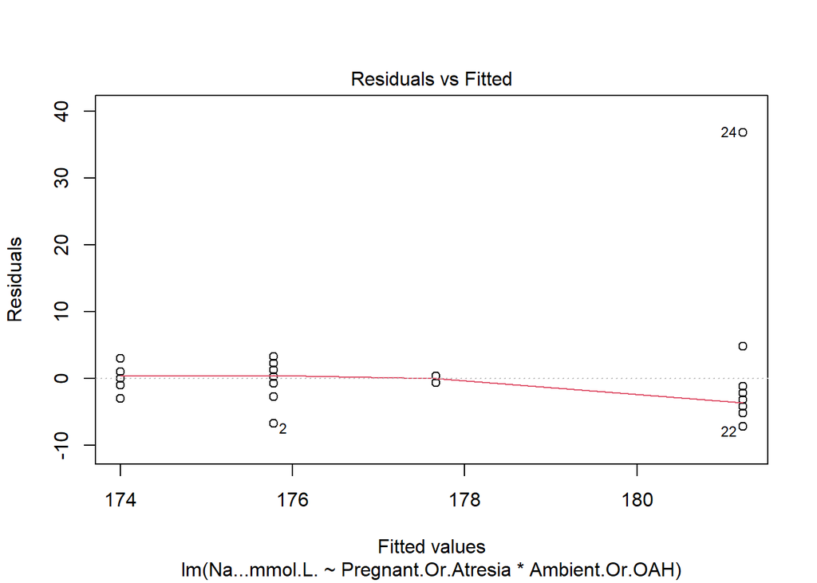

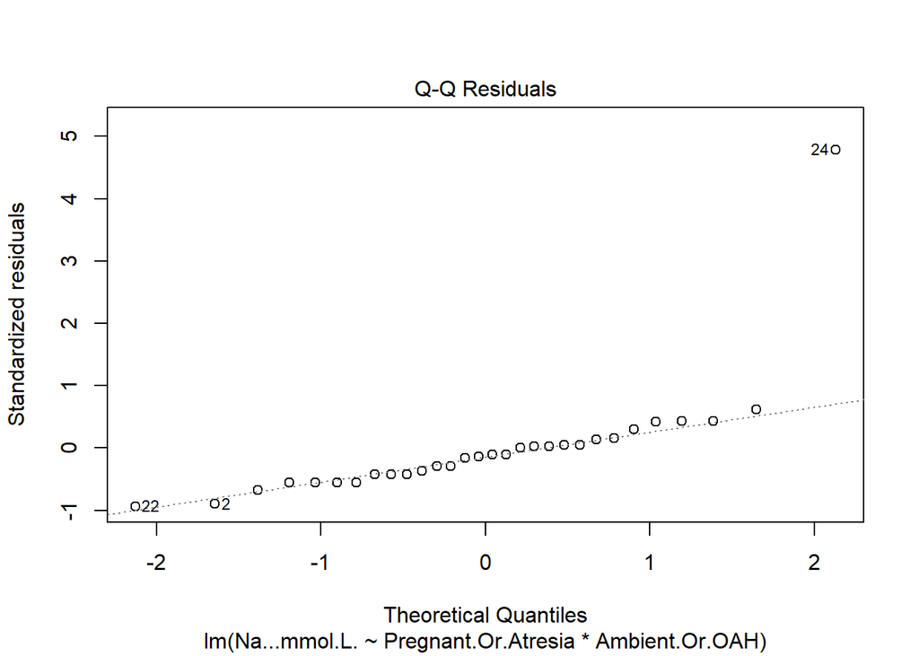

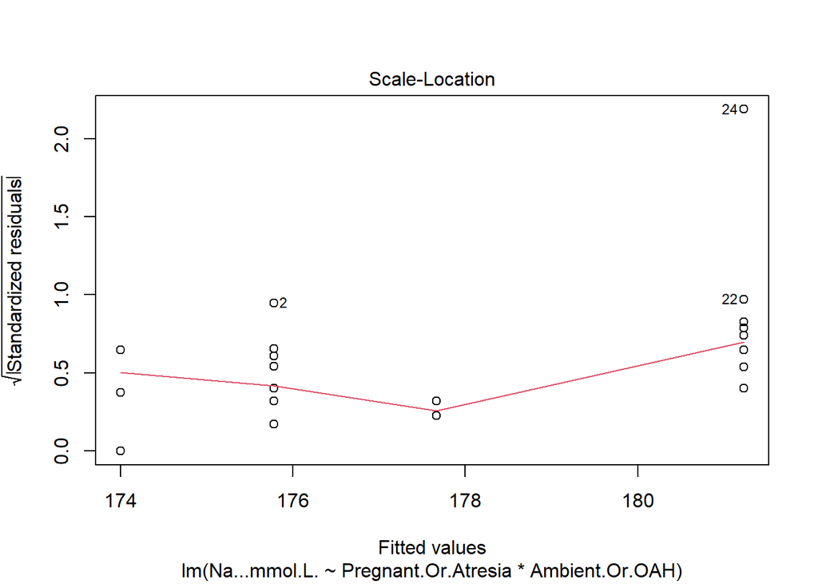

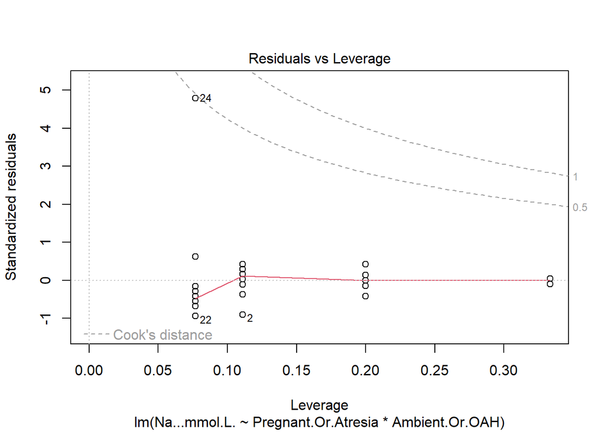

```r
# Sodium: Na+
# Parametric Assumptions
# Assessing Homoscedasticity: Equal Variance of Residuals

# Plotting residuals vs fitted

# Two-way ANOVA Interactive/Additive model: General factor comparison
lm(Na...mmol.L. ~ Pregnant.Or.Atresia * Ambient.Or.OAH, data = General_Samples) %>% plot()
```

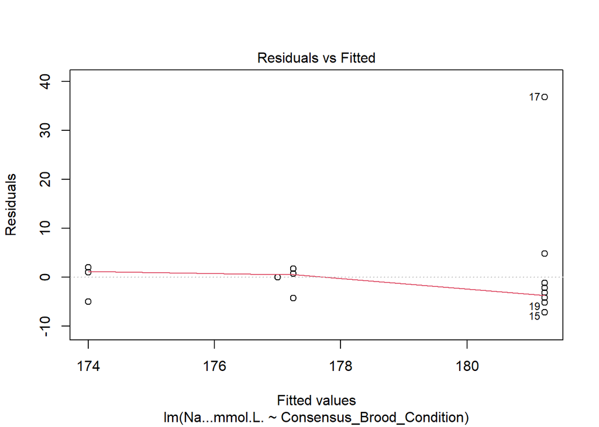

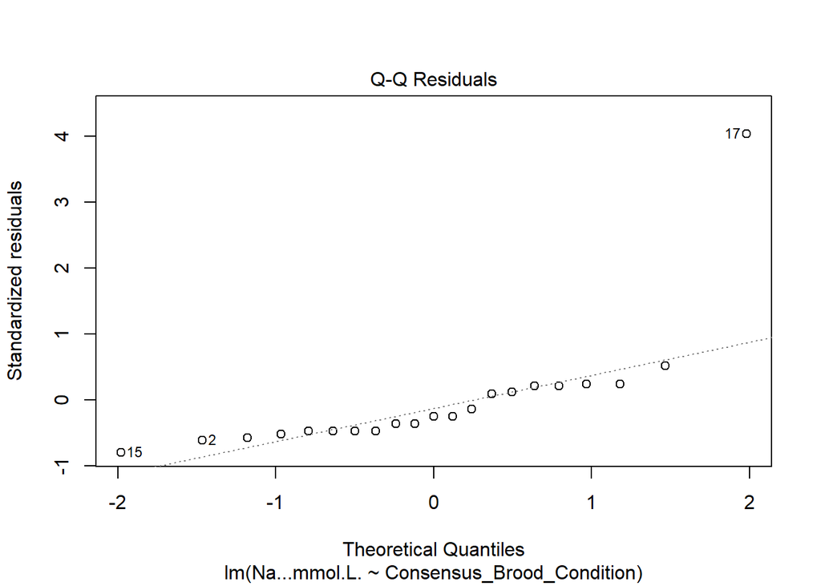

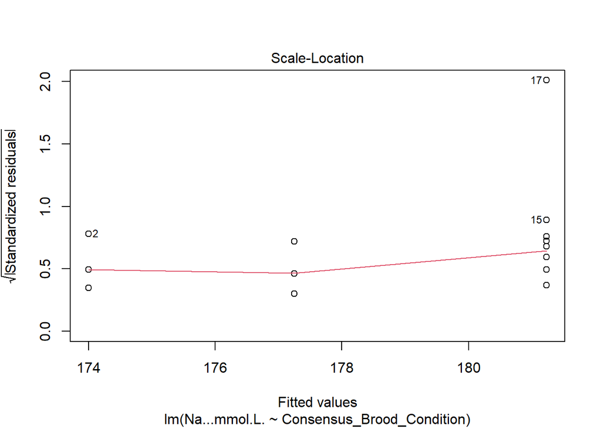

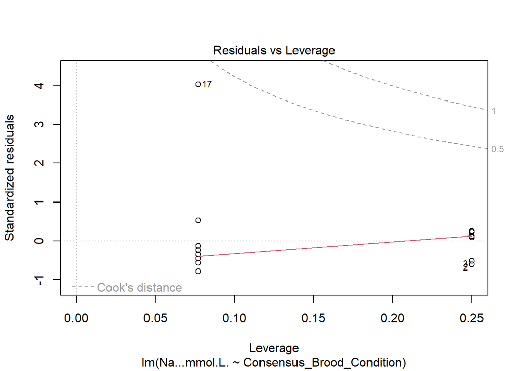

```r
# One-Way ANOVA model: Ambient Parturition Success comparison
lm(Na...mmol.L. ~ Consensus_Brood_Condition, data = Ambient_Only_Samples) %>%
plot()
```

Review residual vs fitted plots (equal variance criteria met?):

General data:

Ambient data:

Sodium Parametric Assessment Scale Location Plot

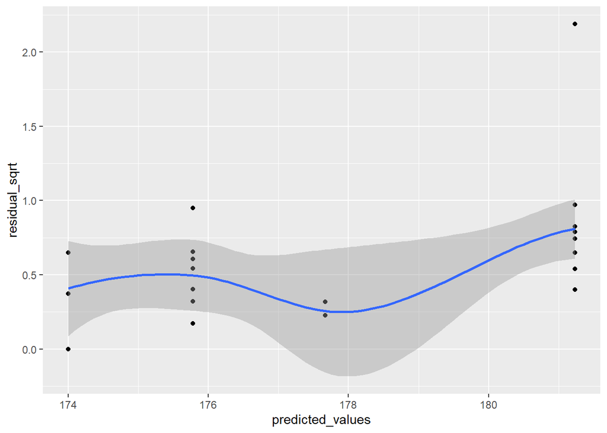

```r
# Sodium: Na+
# Scale location plot

# A flat line stat model is evidence of homoscedasticity, gentle or slight curves are generally accepted as equal variance across samples, however any large, drastic, or sharp changing features to the line suggest heteroscedasticity.
# The degree of slope of the stat model line to which we distinguish between equal or unequal variance across samples is unclear as of yet.


# Scale location plots
# General Samples

General_Samples %>%
  mutate(predicted_values = fitted(sodium_lm_int),
         residual_sqrt = sqrt(abs(rstandard(sodium_lm_int)))) %>%
  ggplot(aes(predicted_values, residual_sqrt)) +
  geom_point() +
  geom_smooth()
```

```
## `geom_line()`: Each group consists of only one observation.
## ℹ Do you need to adjust the group aesthetic?
```

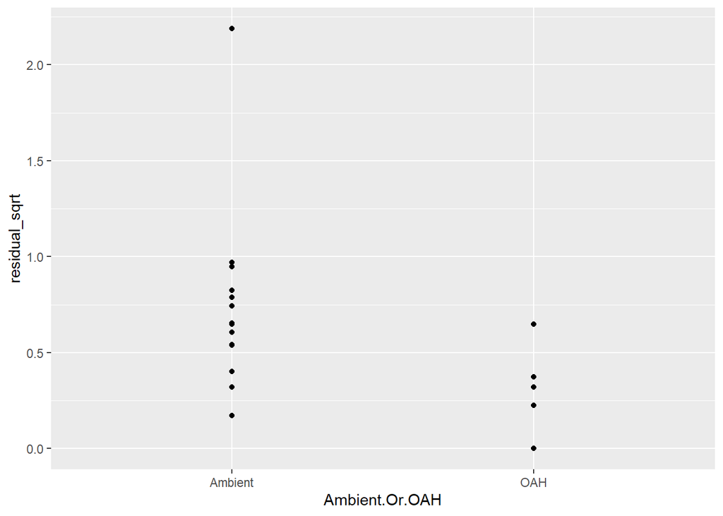

```r
# Compare residuals independently

# General treatment
General_Samples %>%
  mutate(predicted_values = fitted(sodium_lm_int),
         residual_sqrt = sqrt(abs(rstandard(sodium_lm_int)))) %>%
  ggplot(aes(Ambient.Or.OAH, residual_sqrt)) +
  geom_point() +
  stat_summary(geom = "line", fun = mean, color = "red")
```

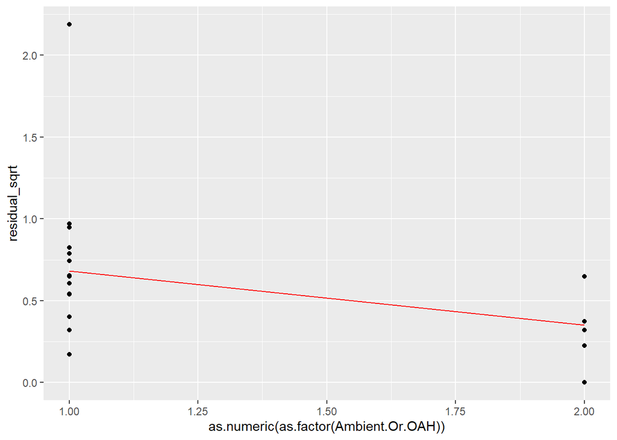

```r
General_Samples %>%
  mutate(predicted_values = fitted(sodium_lm_int),
         residual_sqrt = sqrt(abs(rstandard(sodium_lm_int)))) %>%
  ggplot(aes(as.numeric(as.factor(Ambient.Or.OAH)), residual_sqrt)) +
  geom_point() +
  stat_summary(geom = "line", fun = mean, color = "red")
```

```
## `geom_line()`: Each group consists of only one observation.
## ℹ Do you need to adjust the group aesthetic?
```

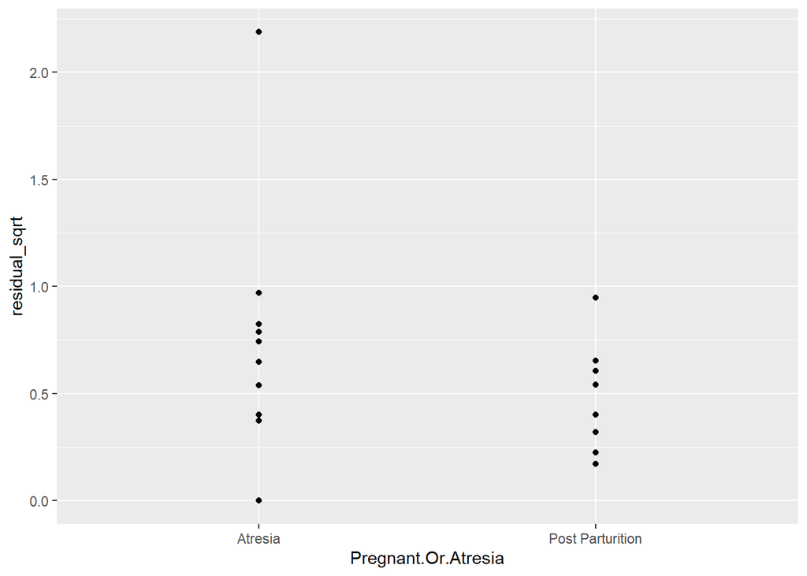

```r
# General parturition outcome
General_Samples %>%
  mutate(predicted_values = fitted(sodium_lm_int),
         residual_sqrt = sqrt(abs(rstandard(sodium_lm_int)))) %>%
  ggplot(aes(Pregnant.Or.Atresia, residual_sqrt)) +
  geom_point() +
  stat_summary(geom = "line", fun = mean, color = "red")
```

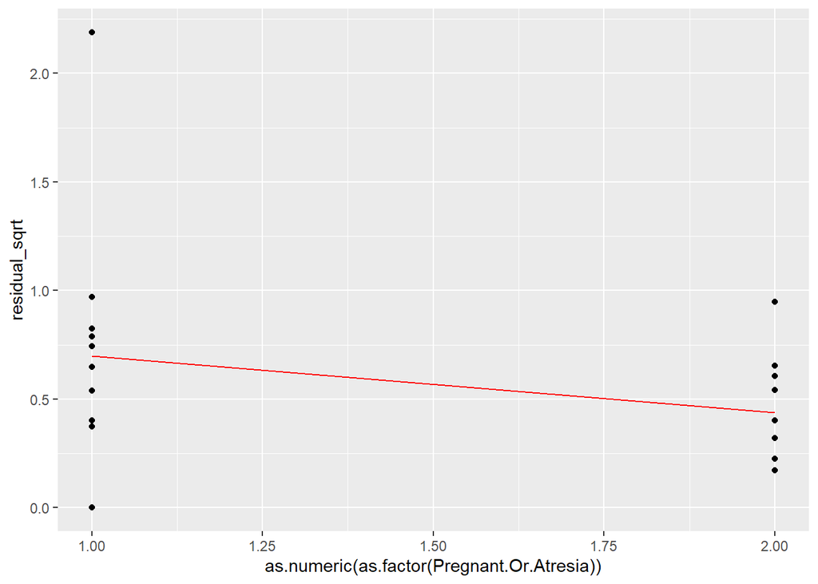

```r
General_Samples %>%
  mutate(predicted_values = fitted(sodium_lm_int),
         residual_sqrt = sqrt(abs(rstandard(sodium_lm_int)))) %>%
  ggplot(aes(as.numeric(as.factor(Pregnant.Or.Atresia)), residual_sqrt)) +
  geom_point() +
  stat_summary(geom = "line", fun = mean, color = "red")
```

Sodium Parametric Assessment Testing Scedasticity:

```r
# Sodium: Na+
# Parametric Assumptions
# Assessing Homoscedasticity: Equal Variance of Residuals

# Testing scedasticity: Options listed below
# - F-test = var.test(): For normally distributed data with two groups only)
# - Bartlett's test = bartlett.test(): For normally distributed data with multiple groups. Sensitive to normality)
# - Levene's Test = leveneTest(): Similar to Bartlett's test, but more robust to variance, less sensitive to normality)
# - Fligner-Killeen test = fligner.test(): A nonparametric test, made to be even more robust against non-normal distributed data
# - Breusch Pagan test = library(lmtest) + bptest(): test for scedasticity in linear regression models


# Bartlett's test
# Note Error Code: Requires at least 2 obs per group

# General samples
bartlett.test(Na...mmol.L. ~ Ambient.Or.OAH, General_Samples)
```

```
##
##  Bartlett test of homogeneity of variances
##
## data:  Na...mmol.L. by Ambient.Or.OAH
## Bartlett's K-squared = 10.118, df = 1, p-value = 0.001469
```

```r
bartlett.test(Na...mmol.L. ~ Pregnant.Or.Atresia, General_Samples)
```

```
##
##  Bartlett test of homogeneity of variances
##
## data:  Na...mmol.L. by Pregnant.Or.Atresia
## Bartlett's K-squared = 14.792, df = 1, p-value = 0.00012
```

```r
leveneTest(Na...mmol.L. ~ Ambient.Or.OAH, General_Samples)
```

```
## Levene's Test for Homogeneity of Variance (center = median)
##       Df F value Pr(>F)
## group  1  0.2984 0.5892
##       28
```

```r
leveneTest(Na...mmol.L. ~ Pregnant.Or.Atresia, General_Samples)
```

```
## Levene's Test for Homogeneity of Variance (center = median)
##       Df F value Pr(>F)
## group  1  0.7495  0.394
##       28
```

```r
# Ambient samples

#bartlett.test(Na...mmol.L. ~ Consensus_Brood_Condition, Ambient_Only_Samples)

leveneTest(Na...mmol.L. ~ Consensus_Brood_Condition, Ambient_Only_Samples)
```

```
## Levene's Test for Homogeneity of Variance (center = median)
##       Df F value Pr(>F)
## group  3  0.2262 0.8769
##       18
```

Review Scedasticity tests (equal variance criteria met?):

General data:

Ambient data:

Summary results of sodium scedasticity (equal variance of residuals):

General data:

Ambient data:

Sodium Conclusions Parametric Assumptions Assessment:

General data:

Ambient data:

# Na+ Stat Tests

Sodium Statistical tests: Two-way anova with general data

```r
# Sodium Analysis
# ANOVA Tests

# Testing general factor differences: Treatment & Parturition Outcome
# Two-Way ANOVA

sodium_aov_int <- aov(Na...mmol.L. ~ Pregnant.Or.Atresia * Ambient.Or.OAH, data = General_Samples)
summary(sodium_aov_int)
```

```
##                                    Df Sum Sq Mean Sq F value Pr(>F)
## Pregnant.Or.Atresia                 1   63.6   63.61   0.996  0.327
## Ambient.Or.OAH                      1   81.5   81.54   1.277  0.269
## Pregnant.Or.Atresia:Ambient.Or.OAH  1  115.3  115.29   1.805  0.191
## Residuals                          26 1660.5   63.87
```

```r
# If Interaction not significant (p-value > 0.05), use additive model

sodium_aov_additive <- aov(Na...mmol.L. ~ Pregnant.Or.Atresia + Ambient.Or.OAH, data = General_Samples)
summary(sodium_aov_additive)
```

```
##                     Df Sum Sq Mean Sq F value Pr(>F)
## Pregnant.Or.Atresia  1   63.6   63.61   0.967  0.334
## Ambient.Or.OAH       1   81.5   81.54   1.240  0.275
## Residuals           27 1775.8   65.77
```

```r
# Post-Hoc Test:
# - Tukey's HSD test (parametric)
# - Scheirer-Ray-Hare test (non-parametric)
# - Aligned Ranked Transformation (ART): Nonparametric, robust against violations to normality and homoscedasticity
# - Ordinal Logistic Regression

# Tukey's Honestly Significant Difference Test (Parametric):
sodium_tukey_test <- TukeyHSD(sodium_aov_int)
print(sodium_tukey_test)
```

```
##   Tukey multiple comparisons of means
##     95% family-wise confidence level
##
## Fit: aov(formula = Na...mmol.L. ~ Pregnant.Or.Atresia * Ambient.Or.OAH, data = General_Samples)
##
## $Pregnant.Or.Atresia
##                               diff       lwr      upr     p adj
## Post Parturition-Atresia -2.972222 -9.094234 3.149789 0.3274991
##
## $Ambient.Or.OAH
##                  diff       lwr      upr     p adj
## OAH-Ambient -3.726326 -10.50843 3.055782 0.2690504
##
## $`Pregnant.Or.Atresia:Ambient.Or.OAH`
##                                                    diff       lwr       upr
## Post Parturition:Ambient-Atresia:Ambient      -5.452991 -14.95973  4.053747
## Atresia:OAH-Atresia:Ambient                   -7.230769 -18.76776  4.306226
## Post Parturition:OAH-Atresia:Ambient          -3.564103 -17.60649 10.478280
## Atresia:OAH-Post Parturition:Ambient          -1.777778 -14.00621 10.450657
## Post Parturition:OAH-Post Parturition:Ambient  1.888889 -12.72689 16.504664
## Post Parturition:OAH-Atresia:OAH               3.666667 -12.34411 19.677447
##                                                   p adj
## Post Parturition:Ambient-Atresia:Ambient      0.4105457
## Atresia:OAH-Atresia:Ambient                   0.3343650
## Post Parturition:OAH-Atresia:Ambient          0.8975723
## Atresia:OAH-Post Parturition:Ambient          0.9780588
## Post Parturition:OAH-Post Parturition:Ambient 0.9843740
## Post Parturition:OAH-Atresia:OAH              0.9220237
```

```r
sodium_aov_int %>% tukey_hsd()
```

```
## # A tibble: 8 × 9
##   term   group1 group2 null.value estimate conf.low conf.high p.adj p.adj.signif
## * <chr>  <chr>  <chr>       <dbl>    <dbl>    <dbl>     <dbl> <dbl> <chr>
## 1 Pregn… Atres… Post …          0    -2.97    -9.09      3.15 0.327 ns
## 2 Ambie… Ambie… OAH             0    -3.73   -10.5       3.06 0.269 ns
## 3 Pregn… Atres… Post …          0    -5.45   -15.0       4.05 0.411 ns
## 4 Pregn… Atres… Atres…          0    -7.23   -18.8       4.31 0.334 ns
## 5 Pregn… Atres… Post …          0    -3.56   -17.6      10.5  0.898 ns
## 6 Pregn… Post … Atres…          0    -1.78   -14.0      10.5  0.978 ns
## 7 Pregn… Post … Post …          0     1.89   -12.7      16.5  0.984 ns
## 8 Pregn… Atres… Post …          0     3.67   -12.3      19.7  0.922 ns
```

Sodium Statistical tests: One-way anova with ambient data

```r
# Sodium: Na+
# ANOVA Tests

# Testing for differences in ambient parturition success metrics
# One-way ANOVA (parametric) or Kruskal-Wallis test (nonparametric)

sodium_aov_ambient <- aov(Na...mmol.L. ~ Consensus_Brood_Condition, data = Ambient_Only_Samples)
summary(sodium_aov_ambient)
```

```
##                           Df Sum Sq Mean Sq F value Pr(>F)
## Consensus_Brood_Condition  3  180.9   60.31   0.671  0.581
## Residuals                 18 1617.1   89.84
```

```r
# Post-Hoc Test:
# - Tukey's HSD (parametric, normality & equal variance across groups)
# - Kruskal Wallis (nonparametric option)
# - Dunn's test (non-parametric, conduct after Kruskal-Wallis test)
```

# Na+ Summary

**Parameter Results Summary**: Deciding upon all evidence (data distribution, visuals, tests, parametric assumptions criteria met or not met): Assumptions, assumptions, assumptions…

# Cl- : Chloride

Chloride Summary Stats

```r
# Chloride: Cl-
# Summary stats

# General data
General_Samples %>%
  group_by(Pregnant.Or.Atresia, Ambient.Or.OAH) %>%
  summarize(count = n(),
            median = round(median(Cl...mmol.L.), 3),
            mean = round(mean(Cl...mmol.L.), 3),
            sd = round(sd(Cl...mmol.L.), 3),
            cv = round(sd(Cl...mmol.L.)/mean(Cl...mmol.L.), 3)) %>%
  ungroup()
```

```
## # A tibble: 4 × 7
##   Pregnant.Or.Atresia Ambient.Or.OAH count median  mean    sd    cv
##   <chr>               <chr>          <int>  <dbl> <dbl> <dbl> <dbl>
## 1 Atresia             Ambient           13    158  158.  4.61 0.029
## 2 Atresia             OAH                5    159  159.  1.79 0.011
## 3 Post Parturition    Ambient            9    156  158.  2.96 0.019
## 4 Post Parturition    OAH                3    162  161.  3.06 0.019
```

```r
# Ambient data
Ambient_Only_Samples %>%
  group_by(Ambient.Or.OAH, Consensus_Brood_Condition) %>%
  summarize(count = n(),
            median = round(median(Cl...mmol.L.), 3),
            mean = round(mean(Cl...mmol.L.), 3),
            sd = round(sd(Cl...mmol.L.), 3),
            cv = round(sd(Cl...mmol.L.)/mean(Cl...mmol.L.), 3)) %>%
  ungroup()
```

```
## # A tibble: 4 × 7
##   Ambient.Or.OAH Consensus_Brood_Condition count median  mean    sd     cv
##   <chr>          <ord>                     <int>  <dbl> <dbl> <dbl>  <dbl>
## 1 Ambient        Excellent                     1    158  158  NA    NA
## 2 Ambient        Normal                        4    160  159.  3.86  0.024
## 3 Ambient        Low                           4    156  156.  0.5   0.003
## 4 Ambient        Atresia                      13    158  158.  4.61  0.029
```

# Cl- Stat Tests

# Cl- Summary

# K+ : Potassium

# K+ Stat Tests

# K+ Summary

# Ca+2 : Calcium

# Ca+2 Stat Tests

# Ca+2 Summary